# Assignmet 2

STATS 220 Semester One 2022

Jeff Hwang

## Introduction

- This report analyses to demonstrate music listening preferences. The survey form collected the data that behaviours related to listening to music, for example, what people prefer to listen to and in what ways do they listen to music. Also, the survey was collected anonymously. I have collected 30 responses and demonstrated music listening preferences depending on ages and music genres. These outcomes will be helpful when targeting music streaming services on ages and genres.

## Links to form and data

CSV link : [Check out the collected data!](https://docs.google.com/spreadsheets/d/e/2PACX-1vR6Z4tIgpPVBpn4DKE-TbHGPOJs5kHAKSIqQz0OGdkQp25U5UDBlqy5NIqTDGJeL1HGktbeDXe8pi4y/pub?output=csv)

Form link : https://docs.google.com/forms/d/e/1FAIpQLSevtM5EIudX0rybmmWAU4-5PjPVzHRugTvKov5IEyzsHoExyw/viewform?usp=sf_link

## Analytics

- The table below shows 5 rows from the data that I collected from students in The University of Auckland.

| Timestamp | age | music_daily | favo_genre | best3_genre | music_import | music_ways | music_streamFee |
| --- | --- | --- | --- | --- | --- | --- | --- |
| 27/03/2022 15:50:06 | 17 or younger | Constantly | Hip-Hop/Rap | Pop, Hip-Hop/Rap, K-Pop | 10 | Spotify | 5 |
| 27/03/2022 16:04:08 | 35-44 | Once | Classical | Classical, Jazz, Instrumental | 3 | CDs | 9 |
| 27/03/2022 16:21:43 | 23-28 | 2-3 times | Pop | Pop, Jazz, Instrumental | 8 | Youtube | 6 |
| 27/03/2022 16:22:37 | 18-22 | 7-10 times | Pop | Pop, Hip-Hop/Rap, K-Pop | 10 | Spotify | 5 |
| 27/03/2022 18:16:40 | 23-28 | 2-3 times | Pop | Pop, K-Pop, Instrumental | 4 | Youtube | 5 |

#### In total, 30 students in The University of Auckland completed music listening preferences form.

#### Plot 1: This plot represents the students picking up a favorite the genre.

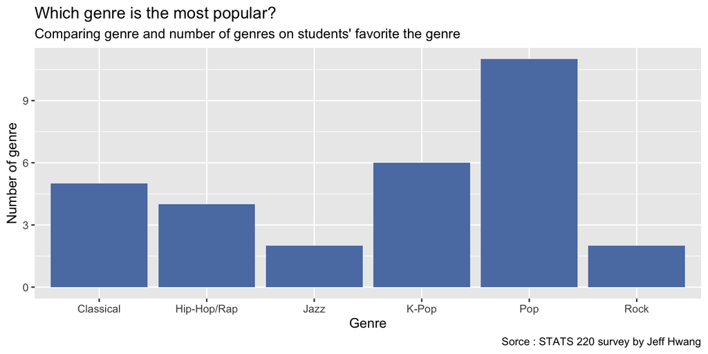

#### Plot 2: This plot shows that how often do students listen to music on a daily basis.

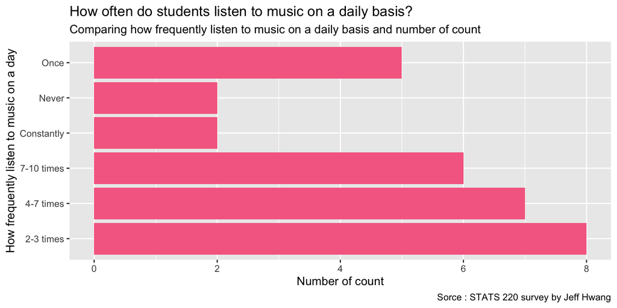

##### This plot above indicates the students most likely listen to music 2-3 times per day.

#### Plot 3: This plot shows that how much do students think about the reasonable price of music streaming services per week.

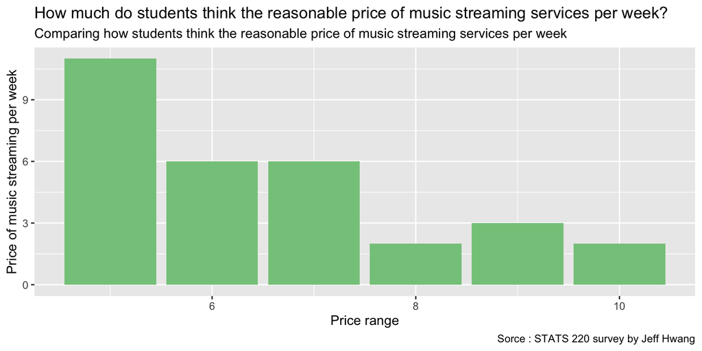

##### The reasonable price that the students think is $5.

##### This plot above presents that the students think the average of the reasonable price is $6.53 for music streaming services per week.

## Learning reflection

- An important idea about a dynamic reporting system is understanding that widely used within markdown and in R code chunks. For instance, we can use in R code chunks like “`{r code here}`” as well as use R code “inline” as part of markdown like `"r code here"`. These methods help analyse the data dynamically even if a subset of the data changes. What I have re-used two techniques from A1 is **linking to websites** for the survey form and CSV file and **building a structured markdown file** that shows clearly. In addition, I am personally curious if we could extract, transform and load from SQL to R. Because it would be helpful not only unnecessary switching the programming language but also to make more efficient work when dealing with the ETL process for the big data in R programming. Also, these technics will be applied Web Development framework for UI, such as data analysis, visualisation and creating graphs dynamically.